# Reporte: Biblioteca Nacional del Perú (2023)

Autor: Luis Alberto Marín Soto

2024-12-24

# 1. Importación de librerías

```r
library(readxl)    # Lectura de archivos excel
library(tidyverse) # Manipulación y visualización de datos
library(DT)        # Interfaz de tablas
library(lubridate) # Manejo de fechas
```

# 2. Carga del dataset

```r
raw_data <- read_excel("DATASET-ORDENES-DE-COMPRA-2023.xlsx")
datatable(head(raw_data), options = list(scrollX = TRUE))
```

|  | FECHACORTE | NRO_ORDEN | FECHA_ORDEN | FECHA_RECEP | NRO_RUC | NOMBRE_PROVEEDOR | PRODUCTO | UNIDAD_DE_MEDIDA | CANTIDAD | PRECIO_UNITARIO | PRECIO_TOTAL | CATEGORIA | DEPENDENCIA |
| --- | --- | --- | --- | --- | --- | --- | --- | --- | --- | --- | --- | --- | --- |
| 1 | 20240115 | 2 | 23/01/2023 00:00:00 | 12/09/2023 00:00:00 | 20601527457 | COMPETROL S.A.C. | GASOLINA DE 98 OCTANOS | GALON | 766.16 | 31.260037 | 23950.19 | GESTIÓN DE LA INFRAESTRUCTURA Y SERVICIOS GENERALES | OFICINA DE ADMINISTRACION |
| 2 | 20240115 | 3 | 23/01/2023 00:00:00 | 12/09/2023 00:00:00 | 20522173933 | GLG INVERSIONES S.A.C. | DIESEL B5 S50 | GALON | 49.91 | 14.970747 | 747.19 | GESTIÓN DE LA INFRAESTRUCTURA Y SERVICIOS GENERALES | OFICINA DE ADMINISTRACION |
| 3 | 20240115 | 4 | 30/01/2023 00:00:00 | 29/12/2023 00:00:00 | 20100176450 | SOLGAS SA | GAS LICUADO DE PETROLEO | GALON | 28553.33 | 6.680003 | 190736.33 | GESTIÓN DE LOS SERVICIOS DE PISCINA Y AUDITORIO | OFICINA DE ADMINISTRACION |
| 4 | 20240115 | 5 | 6/02/2023 00:00:00 | 21/12/2023 00:00:00 | 20117354793 | QUINTO DAMIAN HERMANOS S.A.C | AGUA MINERAL SIN GAS X 20 L | UNIDAD | 2294 | 15.3 | 35098.2 | GESTIÓN DE LOS SERVICIOS BÁSICOS Y OTROS GASTOS COMUNES VINCULADOS A LA OPERATIVIDAD DE LA BNP | OFICINA DE ADMINISTRACION |
| 5 | 20240115 | 6 | 7/02/2023 00:00:00 | 17/02/2023 00:00:00 | 20524483107 | PERUVIAN ANDEAN CRAFT SOCIEDAD ANONIMA CERRADA | TELEFONO SOBRE VOZ IP CON 32 TECLAS | UNIDAD | 2 | 660 | 1320 | ADQUISICION DE EQUIPOS INFORMATICOS PARA LA BIBLIOTECA NACIONAL DEL PERU | OFICINA DE TECNOLOGIA DE LA INFORMACION Y ESTADISTICA |
| 6 | 20240115 | 6 | 7/02/2023 00:00:00 | 17/02/2023 00:00:00 | 20524483107 | PERUVIAN ANDEAN CRAFT SOCIEDAD ANONIMA CERRADA | TELEFONO SOBRE VOZ IP CON MODULO DE EXPANSION | UNIDAD | 1 | 1060 | 1060 | ADQUISICION DE EQUIPOS INFORMATICOS PARA LA BIBLIOTECA NACIONAL DEL PERU | OFICINA DE TECNOLOGIA DE LA INFORMACION Y ESTADISTICA |

### Breve descripción del dataset

Este dataset contiene los datos de las órdenes de compra de la Biblioteca Nacional del Perú del año 2023.

Esta información contiene:

- Número y fecha de la orden.
- Fecha de recepción.
- Numero de RUC y nombres del proveedor.
- Nombre, unidad de medida, cantidad, precio unitario y total del producto adquirido.
- Categoría y dependencia de la orden de compra.

# 3. Exploración del dataset

Primero, observamos el nombre de los encabezados de cada columna.

```r
names(raw_data)
```

```
##  [1] "FECHACORTE"       "NRO_ORDEN"        "FECHA_ORDEN"      "FECHA_RECEP"
##  [5] "NRO_RUC"          "NOMBRE_PROVEEDOR" "PRODUCTO"         "UNIDAD_DE_MEDIDA"
##  [9] "CANTIDAD"         "PRECIO_UNITARIO"  "PRECIO_TOTAL"     "CATEGORIA"
## [13] "DEPENDENCIA"
```

#### Revisión del tipo de variable

A continuación, se muestra el tipo de variable que tiene cada columna.

```r
str(raw_data)
```

```
## tibble [423 × 13] (S3: tbl_df/tbl/data.frame)
##  $ FECHACORTE      : num [1:423] 20240115 20240115 20240115 20240115 20240115 ...
##  $ NRO_ORDEN       : num [1:423] 2 3 4 5 6 6 6 7 7 8 ...
##  $ FECHA_ORDEN     : chr [1:423] "23/01/2023 00:00:00" "23/01/2023 00:00:00" "30/01/2023 00:00:00" "6/02/2023 00:00:00" ...
##  $ FECHA_RECEP     : chr [1:423] "12/09/2023 00:00:00" "12/09/2023 00:00:00" "29/12/2023 00:00:00" "21/12/2023 00:00:00" ...
##  $ NRO_RUC         : chr [1:423] "20601527457" "20522173933" "20100176450" "20117354793" ...
##  $ NOMBRE_PROVEEDOR: chr [1:423] "COMPETROL S.A.C." "GLG INVERSIONES S.A.C." "SOLGAS SA" "QUINTO DAMIAN HERMANOS S.A.C" ...
##  $ PRODUCTO        : chr [1:423] "GASOLINA DE 98 OCTANOS" "DIESEL B5 S50" "GAS LICUADO DE PETROLEO" "AGUA MINERAL SIN GAS X 20 L" ...
##  $ UNIDAD_DE_MEDIDA: chr [1:423] "GALON" "GALON" "GALON" "UNIDAD" ...
##  $ CANTIDAD        : num [1:423] 766.2 49.9 28553.3 2294 2 ...
##  $ PRECIO_UNITARIO : num [1:423] 31.26 14.97 6.68 15.3 660 ...
##  $ PRECIO_TOTAL    : num [1:423] 23950 747 190736 35098 1320 ...
##  $ CATEGORIA       : chr [1:423] "GESTIÓN DE LA INFRAESTRUCTURA Y SERVICIOS GENERALES" "GESTIÓN DE LA INFRAESTRUCTURA Y SERVICIOS GENERALES" "GESTIÓN DE LOS SERVICIOS DE PISCINA Y AUDITORIO" "GESTIÓN DE LOS SERVICIOS BÁSICOS Y OTROS GASTOS COMUNES VINCULADOS A LA OPERATIVIDAD DE LA BNP" ...
##  $ DEPENDENCIA     : chr [1:423] "OFICINA DE  ADMINISTRACION" "OFICINA DE  ADMINISTRACION" "OFICINA DE  ADMINISTRACION" "OFICINA DE  ADMINISTRACION" ...
```

Vamos a pasar las columnas “FECHA_ORDEN” y “FECHA_RECEP” a formato fecha.

```r
raw_data$FECHA_ORDEN <- as.Date(raw_data$FECHA_ORDEN, format="%d/%m/%Y")
raw_data$FECHA_RECEP <- as.Date(raw_data$FECHA_RECEP, format="%d/%m/%Y")
```

Ahora, cambiaremos el formato de la fecha a “año-mes”.

```r
raw_data$FECHA_ORDEN <- format(raw_data$FECHA_ORDEN, "%Y-%m")
```

#### Resumen de estadísticas descriptivas

```r
summary(raw_data)
```

```
##    FECHACORTE         NRO_ORDEN      FECHA_ORDEN         FECHA_RECEP
##  Min.   :20240115   Min.   :  2.00   Length:423         Min.   :2023-02-08
##  1st Qu.:20240115   1st Qu.: 45.00   Class :character   1st Qu.:2023-05-18
##  Median :20240115   Median : 90.00   Mode  :character   Median :2023-08-21
##  Mean   :20240115   Mean   : 82.87                      Mean   :2023-08-14
##  3rd Qu.:20240115   3rd Qu.:106.50                      3rd Qu.:2023-11-14
##  Max.   :20240115   Max.   :179.00                      Max.   :2023-12-29
##                                                         NA's   :3
##    NRO_RUC          NOMBRE_PROVEEDOR     PRODUCTO         UNIDAD_DE_MEDIDA
##  Length:423         Length:423         Length:423         Length:423
##  Class :character   Class :character   Class :character   Class :character
##  Mode  :character   Mode  :character   Mode  :character   Mode  :character
##
##
##
##
##     CANTIDAD      PRECIO_UNITARIO     PRECIO_TOTAL       CATEGORIA
##  Min.   :     1   Min.   :     0.0   Min.   :     2.7   Length:423
##  1st Qu.:     2   1st Qu.:     4.3   1st Qu.:   205.6   Class :character
##  Median :    20   Median :    36.4   Median :   817.1   Mode  :character
##  Mean   :  1425   Mean   :  4816.8   Mean   : 11045.2
##  3rd Qu.:   100   3rd Qu.:   494.5   3rd Qu.:  4261.0
##  Max.   :190000   Max.   :399373.3   Max.   :457000.0
##
##  DEPENDENCIA
##  Length:423
##  Class :character
##  Mode  :character
##
##
##
##
```

# 4. Limpieza de datos

### 4.1. Detección de valores NA

```r
colSums(is.na(raw_data))
```

```
##       FECHACORTE        NRO_ORDEN      FECHA_ORDEN      FECHA_RECEP
##                0                0                0                3
##          NRO_RUC NOMBRE_PROVEEDOR         PRODUCTO UNIDAD_DE_MEDIDA
##                0                0                0                0
##         CANTIDAD  PRECIO_UNITARIO     PRECIO_TOTAL        CATEGORIA
##                0                0                0                0
##      DEPENDENCIA
##                0
```

### 4.2. Detección de filas duplicadas

Inicialmente, nuestra tabla tiene 423 filas y 13 columnas. Para observar mejor el posible cambio, se va a generar otra variable llamada “raw_data1”.

```r
raw_data1 <- raw_data %>%
  distinct()
```

Finalmente, después de eliminar las filas duplicadas, tenemos 423 filas y 13 columnas. Por lo tanto, no existieron duplicados.

### 4.3. Columnas irrelevantes

Para este caso, hay columnas que no vamos a utilizar para analizar. Así que vamos a eliminar algunas para reducir el tamaño de nuestro dataset. A nuestro nuevo dataset lo llamaremos “raw_data2”.

Se procede a eliminar las columnas como “FECHACORTE”, “FECHARECEP”, “NRO_RUC”, UNIDAD_DE_MEDIDA” y “PRECIO_UNITARIO”

```r
raw_data2 <- raw_data1 %>%
  select(-c(1, 4, 5, 8, 10))
View(raw_data2)
```

### 4.4. Detección de errores tipográficos

A continuación, se puede ver que hay dos veces “CARTULINA SIMPLE 140 g TAMAÑO A4” debido a un error al momento de introducir la observación, se registró con dos espacios entre TAMAÑO y A4.

```r
raw_data2 %>%
  select(PRODUCTO) %>%
  filter(str_starts(PRODUCTO, "CART"))
```

```
## # A tibble: 7 × 1
##   PRODUCTO
##   <chr>
## 1 CARTUCHO LIMPIADOR PARA HP  COD. REF. C7978A
## 2 CARTULINA SIMPLE 140 g TAMAÑO  A4
## 3 CARTUCHO DE MANTENIMIENTO PARA XEROX COD. REF. 106R01081
## 4 CARTULINA SIMPLE 140 g TAMAÑO A4
## 5 CARTULINA FINA 150 g TAMAÑO A3
## 6 CARTON GRIS CALIBRE 16  DE 1 m X 70 cm
## 7 CARTULINA TIPO CANSON 150 G DE 50 CM X 65 CM COLOR GRIS CLARO
```

```r
raw_data2 %>% group_by(PRODUCTO) %>% summarise(suma = sum(CANTIDAD)) %>% arrange(desc(suma))
```

```
## # A tibble: 371 × 2
##    PRODUCTO                                                     suma
##    <chr>                                                       <dbl>
##  1 CARTULINA SIMPLE 140 g TAMAÑO A4                          190000
##  2 CONTRATAPA PLASTIFICADA DE CARTON PARA ANILLADO TAMAÑO A4 120000
##  3 CARTULINA FINA 150 g TAMAÑO A3                             95000
##  4 ETIQUETA AUTOADHESIVA 5 CM X 2.5 CM                        50000
##  5 ESPIRAL DE PLASTICO 30 MM                                  45000
##  6 GAS LICUADO DE PETROLEO                                    28553.
##  7 GORRO QUIRURGICO DESCARTABLE                                6000
##  8 GUANTE DE NAILON CON PALMA DE NITRILO TALLA L               6000
##  9 GUANTE DE NAILON CON PALMA DE NITRILO TALLA M               6000
## 10 GUANTE DE NAILON CON PALMA DE NITRILO TALLA S               6000
## # ℹ 361 more rows
```

Si dejamos pasar este error el programa va a contabilizar de forma incorrecta. Así que vamos a corregirlo. Generaremos una nueva variable llamada “raw_data3” para almacenar la información corregida.

```r
raw_data3 <- raw_data2 %>%
  mutate(PRODUCTO = str_squish(PRODUCTO))
```

Haciendo un nuevo conteo de las cantidades.

```r
raw_data3 %>% group_by(PRODUCTO) %>% summarise(suma = sum(CANTIDAD)) %>% arrange(desc(suma))
```

```
## # A tibble: 370 × 2
##    PRODUCTO                                                     suma
##    <chr>                                                       <dbl>
##  1 CARTULINA SIMPLE 140 g TAMAÑO A4                          190040
##  2 CONTRATAPA PLASTIFICADA DE CARTON PARA ANILLADO TAMAÑO A4 120000
##  3 CARTULINA FINA 150 g TAMAÑO A3                             95000
##  4 ETIQUETA AUTOADHESIVA 5 CM X 2.5 CM                        50000
##  5 ESPIRAL DE PLASTICO 30 MM                                  45000
##  6 GAS LICUADO DE PETROLEO                                    28553.
##  7 GORRO QUIRURGICO DESCARTABLE                                6000
##  8 GUANTE DE NAILON CON PALMA DE NITRILO TALLA L               6000
##  9 GUANTE DE NAILON CON PALMA DE NITRILO TALLA M               6000
## 10 GUANTE DE NAILON CON PALMA DE NITRILO TALLA S               6000
## # ℹ 360 more rows
```

### 4.5. Detección de *Outliers*

Veamos si existen valores *Outliers* o atípicos en nuestra variable a trabajar: “PRECIO_TOTAL”; mediante un gráfico tipo boxplot.

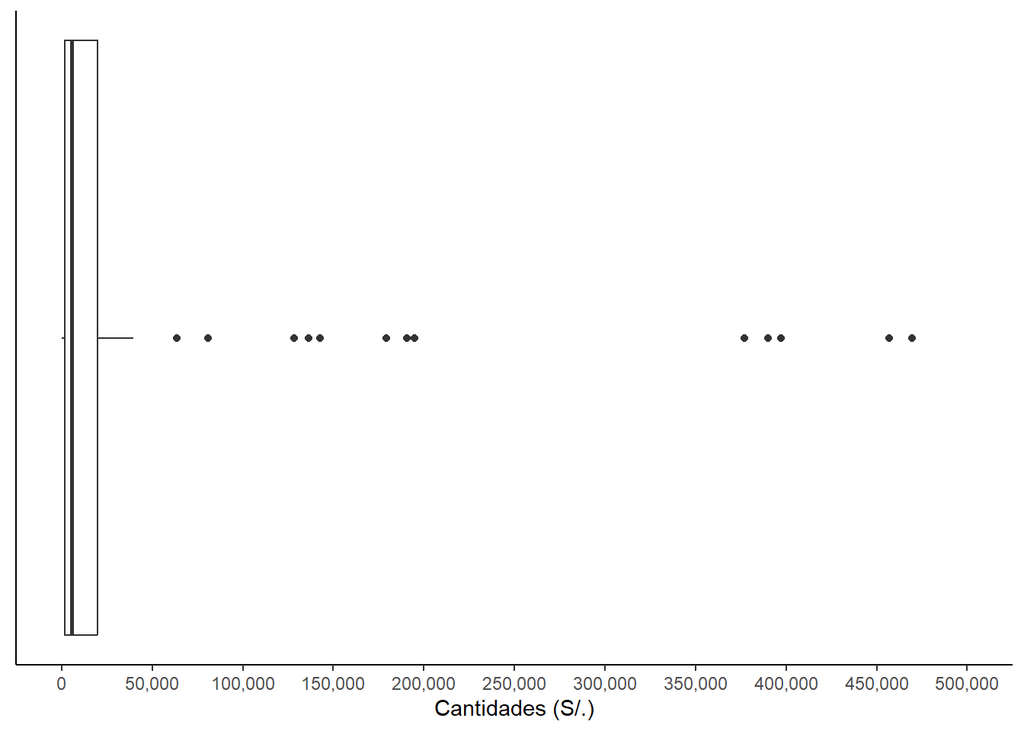

```r
raw_data3 %>%
  group_by(NRO_ORDEN) %>%
  summarise(total = sum(PRECIO_TOTAL)) %>%
  ggplot(aes(total)) +
  geom_boxplot() +
  scale_x_continuous(labels = scales::comma,
                     breaks = seq(0, 500000, 50000),
                     limits = c(0, 500000)) +
  labs(
    x = "Cantidades (S/.)",
  ) +
  theme_classic() +
  theme(
    axis.text.y = element_blank(),
    axis.ticks.y = element_blank()
  )
```

Si bien hay presencia de *Outliers*, en este caso, no se tocarán porque se usarán para la generación de un gráfico. Además, estas cantidades pueden ser obtenidas en la realidad.

Por último, teniendo ya nuestros datos preparados vamos a almacenarlo en la variable llamada “cleaned_data”

```r
cleaned_data <- raw_data3
```

Veamos como queda nuestro dataset después de todos los cambios efectuados.

```r
datatable(head(cleaned_data), options = list(scrollX = TRUE))
```

|  | NRO_ORDEN | FECHA_ORDEN | NOMBRE_PROVEEDOR | PRODUCTO | CANTIDAD | PRECIO_TOTAL | CATEGORIA | DEPENDENCIA |
| --- | --- | --- | --- | --- | --- | --- | --- | --- |
| 1 | 2 | 2023-01 | COMPETROL S.A.C. | GASOLINA DE 98 OCTANOS | 766.16 | 23950.19 | GESTIÓN DE LA INFRAESTRUCTURA Y SERVICIOS GENERALES | OFICINA DE ADMINISTRACION |
| 2 | 3 | 2023-01 | GLG INVERSIONES S.A.C. | DIESEL B5 S50 | 49.91 | 747.19 | GESTIÓN DE LA INFRAESTRUCTURA Y SERVICIOS GENERALES | OFICINA DE ADMINISTRACION |
| 3 | 4 | 2023-01 | SOLGAS SA | GAS LICUADO DE PETROLEO | 28553.33 | 190736.33 | GESTIÓN DE LOS SERVICIOS DE PISCINA Y AUDITORIO | OFICINA DE ADMINISTRACION |
| 4 | 5 | 2023-02 | QUINTO DAMIAN HERMANOS S.A.C | AGUA MINERAL SIN GAS X 20 L | 2294 | 35098.2 | GESTIÓN DE LOS SERVICIOS BÁSICOS Y OTROS GASTOS COMUNES VINCULADOS A LA OPERATIVIDAD DE LA BNP | OFICINA DE ADMINISTRACION |
| 5 | 6 | 2023-02 | PERUVIAN ANDEAN CRAFT SOCIEDAD ANONIMA CERRADA | TELEFONO SOBRE VOZ IP CON 32 TECLAS | 2 | 1320 | ADQUISICION DE EQUIPOS INFORMATICOS PARA LA BIBLIOTECA NACIONAL DEL PERU | OFICINA DE TECNOLOGIA DE LA INFORMACION Y ESTADISTICA |
| 6 | 6 | 2023-02 | PERUVIAN ANDEAN CRAFT SOCIEDAD ANONIMA CERRADA | TELEFONO SOBRE VOZ IP CON MODULO DE EXPANSION | 1 | 1060 | ADQUISICION DE EQUIPOS INFORMATICOS PARA LA BIBLIOTECA NACIONAL DEL PERU | OFICINA DE TECNOLOGIA DE LA INFORMACION Y ESTADISTICA |

# 5. Visualización de datos

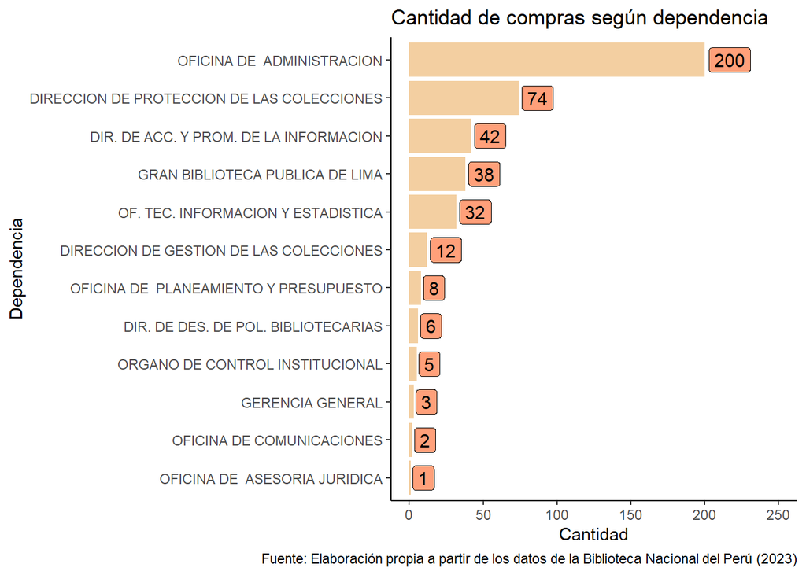

```r
cleaned_data %>%
  mutate(DEPENDENCIA = recode(DEPENDENCIA,
                              "OFICINA DE TECNOLOGIA DE LA INFORMACION Y ESTADISTICA" = "OF. TEC. INFORMACION Y ESTADISTICA",
                              "DIRECCION DEL ACCESO Y PROMOCION DE LA INFORMACION" = "DIR. DE ACC. Y PROM. DE LA INFORMACION",
                              "DIRECCION DE DESARROLLO DE POLITICAS BIBLIOTECARIAS" = " DIR. DE DES. DE POL. BIBLIOTECARIAS")) %>%
  ggplot(aes(fct_rev(fct_infreq(DEPENDENCIA)))) +
  geom_bar(fill = "#F3CFA1") +
  geom_label(stat = "count", aes(label = after_stat(count)), fill = "#FFA07A",
             color = "black", hjust = -0.1, size = 4) +
  scale_y_continuous(limits = c(0, 250)) +
  coord_flip() +
  theme_classic() +
  labs(x = "Dependencia",
       y = "Cantidad",
       title = "Cantidad de compras según dependencia",
       caption = "Fuente: Elaboración propia a partir de los datos de la Biblioteca Nacional del Perú (2023)")
```

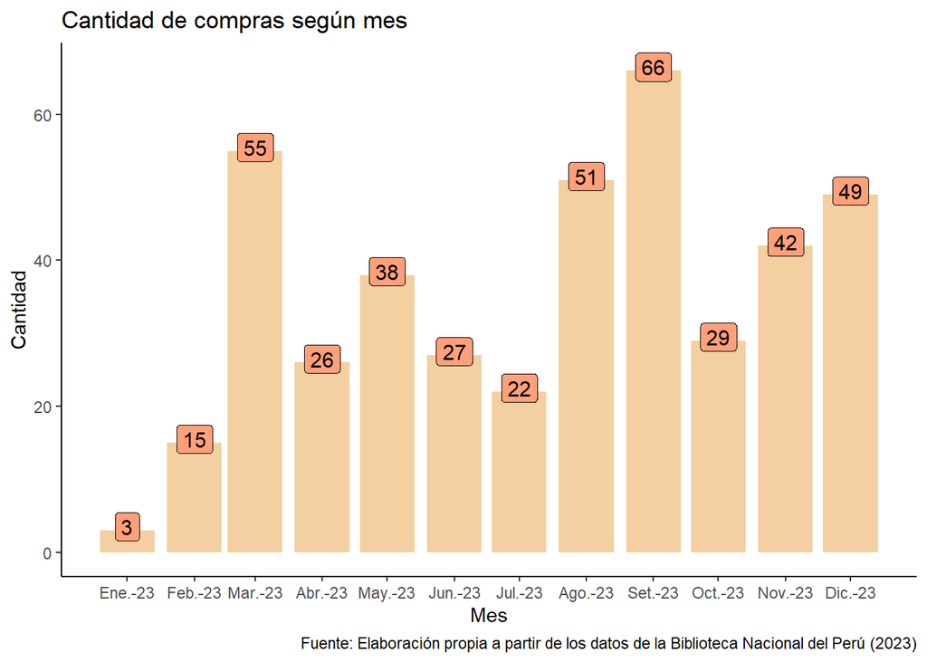

```r
cleaned_data %>%
  group_by(FECHA_ORDEN) %>%
  summarise(cantidad = n()) %>%
  mutate(FECHA_ORDEN = ymd(paste0(FECHA_ORDEN, "-01"))) %>%
           complete(FECHA_ORDEN = seq.Date(ymd("2023-01-01"), ymd("2023-12-01"),
                                           by = "month"), fill = list(cantidad = 0)) %>%
  ggplot(aes(FECHA_ORDEN, cantidad)) +
  geom_col(fill = "#F3CFA1") +
  geom_label(aes(label = cantidad), fill = "#FFA07A",
             color = "black", size = 4, nudge_y = 0.5) +
  scale_x_date(date_breaks = "1 month", date_labels = "%b-%y") +
  theme_classic() +
  labs(x = "Mes",
       y = "Cantidad",
       title = "Cantidad de compras según mes",
       caption = "Fuente: Elaboración propia a partir de los datos de la Biblioteca Nacional del Perú (2023)")
```

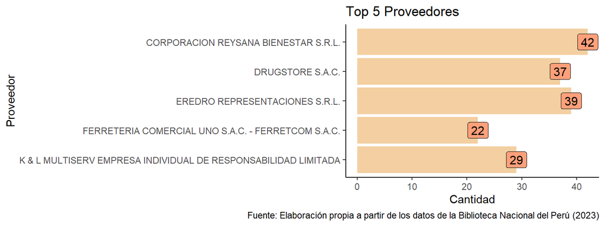

```r
cleaned_data %>%
  group_by(NOMBRE_PROVEEDOR) %>%
  summarise(conteo = n()) %>%
  filter(conteo > 20) %>%
  ggplot(aes(fct_rev(fct_infreq(NOMBRE_PROVEEDOR)), conteo)) +
  geom_col(fill = "#F3CFA1") +
  geom_label(aes(label = conteo), fill = "#FFA07A",
             color = "black", hjust = 0.5, size = 4) +
  coord_flip() +
  theme_classic() +
  labs(x = "Proveedor",
       y = "Cantidad",
       title = "Top 5 Proveedores",
       caption = "Fuente: Elaboración propia a partir de los datos de la Biblioteca Nacional del Perú (2023)")
```

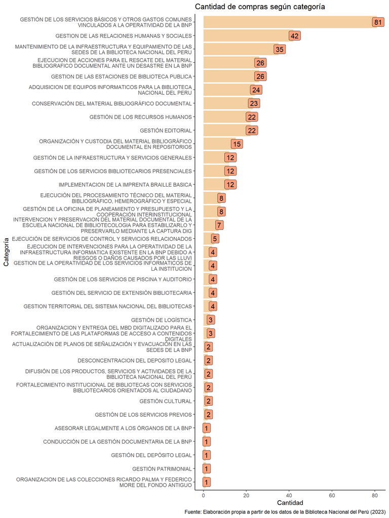

```r
cleaned_data %>%
    mutate(CATEGORIA = str_wrap(CATEGORIA, width = 60)) %>%
  ggplot(aes(fct_rev(fct_infreq(CATEGORIA)))) +
  geom_bar(fill = "#F3CFA1") +
  geom_label(stat = "count", aes(label = after_stat(count)), fill = "#FFA07A",
             color = "black", hjust = 0.4, size = 4) +
  coord_flip() +
  theme_classic() +
  labs(x = "Categoría",
       y = "Cantidad",
       title = "Cantidad de compras según categoría",
       caption = "Fuente: Elaboración propia a partir de los datos de la Biblioteca Nacional del Perú (2023)")
```

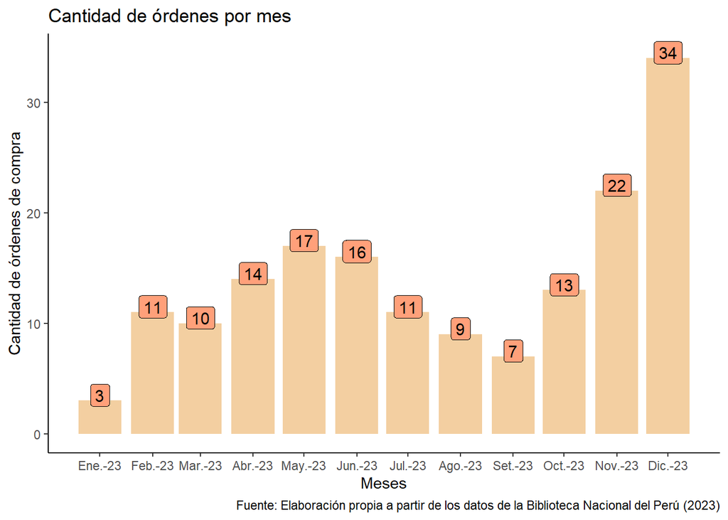

```r
cleaned_data %>%
  group_by(FECHA_ORDEN) %>%
  distinct(NRO_ORDEN) %>%
  summarise(conteo = n()) %>%
  mutate(FECHA_ORDEN = ymd(paste0(FECHA_ORDEN, "-01"))) %>%
  ggplot(aes(FECHA_ORDEN, conteo)) +
  geom_col(fill = "#F3CFA1") +
    geom_label(aes(label = conteo), fill = "#FFA07A",
             color = "black", size = 4, nudge_y = 0.5) +
  scale_x_date(date_breaks = "1 month", date_labels = "%b-%y") +
  theme_classic() +
  labs(x = "Meses",
       y = "Cantidad de órdenes de compra",
       title = "Cantidad de órdenes por mes",
       caption = "Fuente: Elaboración propia a partir de los datos de la Biblioteca Nacional del Perú (2023)")
```

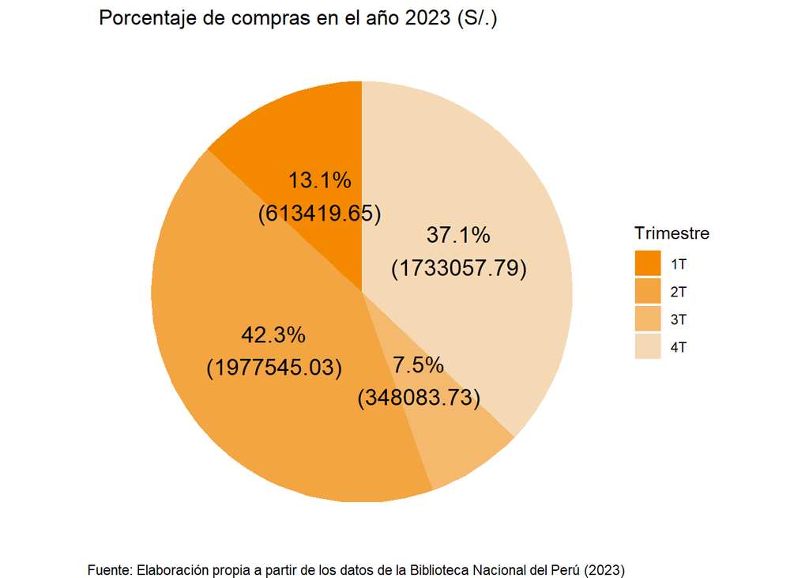

```r
cleaned_data %>%
  mutate(FECHA_ORDEN = ymd(paste0(FECHA_ORDEN, "-01"))) %>%
  mutate(
    trimestre = case_when(
      month(FECHA_ORDEN) <= 3 ~ "1T",
      month(FECHA_ORDEN) <= 6 ~ "2T",
      month(FECHA_ORDEN) <= 9 ~ "3T",
      TRUE ~ "4T"
    )
  ) %>%
  group_by(trimestre) %>%
  summarise(ventas = sum(PRECIO_TOTAL)) %>%
  mutate(
    porcentaje = ventas/sum(ventas)*100,
    etiqueta = paste0(round(porcentaje, 1), "%\n(", ventas, ")")
  ) %>%
  ggplot(aes(x = "", y = porcentaje, fill = trimestre)) +
  geom_bar(width = 1, stat = "identity") +
  coord_polar(theta = "y") +
  geom_text(aes(label = etiqueta), position = position_stack(vjust = 0.5), size = 5) +
  scale_fill_manual(values = c("1T" = "#F48900", "2T" = "#F3A541",
                               "3T" = "#F5B96D", "4T" = "#F5D9B5")) +
  labs(
    title = "Porcentaje de compras en el año 2023 (S/.)",
    fill = "Trimestre",
    caption = "Fuente: Elaboración propia a partir de los datos de la Biblioteca Nacional del Perú (2023)"
  ) +
  theme_void()
```

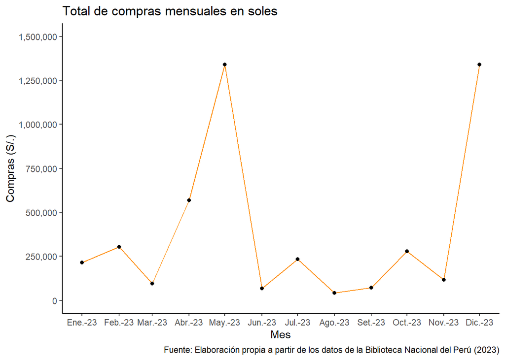

```r
cleaned_data %>%
  group_by(FECHA_ORDEN) %>%
  summarise(compras_totales = (sum(PRECIO_TOTAL))) %>%
  mutate(FECHA_ORDEN = ymd(paste0(FECHA_ORDEN, "-01"))) %>%
  ggplot(aes(FECHA_ORDEN, compras_totales)) +
  geom_line(col = "darkorange") +
  geom_point() +
  scale_x_date(date_breaks = "1 month", date_labels = "%b-%y") +
  scale_y_continuous(labels = scales::comma,
                     breaks = seq(0, 1500000, 250000),
                     limits = c(0, 1500000)) +
  theme_classic() +
  labs(x = "Mes",
       y = "Compras (S/.)",
       title = "Total de compras mensuales en soles",
       caption = "Fuente: Elaboración propia a partir de los datos de la Biblioteca Nacional del Perú (2023)")
```

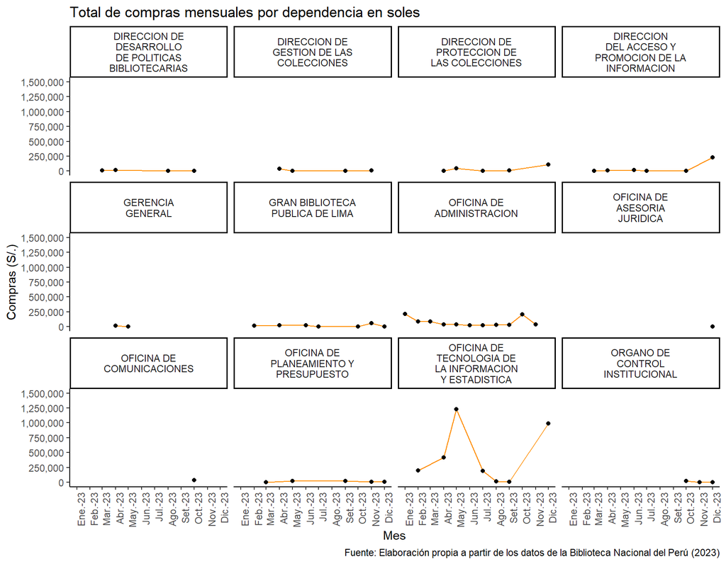

```r
cleaned_data %>%
  group_by(DEPENDENCIA, FECHA_ORDEN) %>%
  summarise(compras_totales = (sum(PRECIO_TOTAL))) %>%
  mutate(FECHA_ORDEN = ymd(paste0(FECHA_ORDEN, "-01")),
         DEPENDENCIA = str_wrap(DEPENDENCIA, width = 15)) %>%
  ggplot(aes(FECHA_ORDEN, compras_totales)) +
  geom_line(col = "darkorange") +
  geom_point() +
  facet_wrap(~DEPENDENCIA) +
  scale_x_date(date_breaks = "1 month", date_labels = "%b-%y") +
  scale_y_continuous(labels = scales::comma,
                     breaks = seq(0, 1500000, 250000),
                     limits = c(0, 1500000)) +
  theme_classic() +
  theme(axis.text.x = element_text(angle = 90, hjust = 1)) +
  labs(x = "Mes",
       y = "Compras (S/.)",
       title = "Total de compras mensuales por dependencia en soles",
       caption = "Fuente: Elaboración propia a partir de los datos de la Biblioteca Nacional del Perú (2023)")
```

# 6. Conclusiones

- Durante todo el año 2023, la oficina de administración fue la dependencia que hizo muchas más compra que las demás dependencias.
- Durante el tercer trimestre, se registraron en total 139 compras, siendo esta la mayor.
- De los 5 primeros proveedores, Corporación Reysana Bienestar S.R.L fue el mayor proveedor de productos a la Biblioteca Nacional del Perú.
- La categoría “servicios básicos y otros gastos comunes” ostenta la mayor cantidad de compras hechas en ese año.
- En el mes de diciembre se registraron la mayor cantidad de órdenes de compra emitidas, mientras que en enero, la menor.
- El primer y tercer trimestre representaron los niveles más bajos en gastos de compras en todo el año 2023.
- En mayo y diciembre se reportaron los meses con más altos gastos en el transcurso del año.
- Si bien la oficina de administración hizo compras de forma mensual, la oficina de tecnología de la información y estadística fue la que mayores gastos hizo.

# 7. Pagina web del dataset

Enlace: https://www.datosabiertos.gob.pe/dataset/%C3%B3rdenes-de-compra-de-la-biblioteca-nacional-del-per%C3%BA-%E2%80%93-bnp